## MA2102

# Probability and Statistics

#### Lecture-4

Pretty much everyone these days is familiar with concept of probability. People discuss probabilities of winning a lottery. A gambler wants to know if the game(gambling) is fair to bet by computing odds of winning the game. A bank wants to calculate probability a loan will be repaid by looking at applicant credit history. A drug company calculate the probability of harmful side effects of drugs by using data that is obtained by doing series of tests on people.  
Mathematics is the logic of certainty, but Probability is the logic of uncertainty.And life is uncertain,so we can make better decisions in life by carrying out these probability calculations for everyday events.

*Why study probability and statistics as computer science student?*

- *Machine Learning* :Developing algorithms (called Machine learning algorithms) to make machines(computers) get better at particular task by learning from data(examples), without explicitly programming rules about the task.  
  Example:Spam filter(classification(supervised learning) algorithm) able to classify (using Baye's theorem) whether incoming email spam or not from experience of having seen a lot of examples of spam emails and ham(nonspam) emails.
- *Analysis of Algorithms*:Finding average time complexity of an algorithm provided we know the probability distribution of inputs. And Probability is an essential tool for analysing(studying performance of algorithm) randomized algorithms (an algorithm that make random choice in some part of its logic).

**Example of a Probability problem:** Let us say you are about to give a test consisting of 100 GK(General Knowledge) Multiple choice questions(MCQ) (with four options and no negative marking) and you believe that you have zero knowledge about GK( you won't even bothered to read question to answer, you will just pick a random option), then what is the probability that you will score at least 30. (answer will be 0.1037872 as we will compute(using Binomial distribution) later in this course)  
**Example of a Statistics problem:** Let us say you attempted a test consisting of 100 General Knowledge Multiple choice questions(MCQ) (with four options and no negative marking) and you have have some knowledge about GK (so you do read questions before you pick answer) and you scored 60. Using (inferential)statistics one has to draw conclusions(inferences) from this data that how good you are at GK means estimating parameter(a characteristic about your GK), say $p$ that represent a probability you answering a random GK question correctly.(using sampled data (performance over 100 random GK questions) one can infer(using inferential statistics) that $p\approx0.6$)

The probability theory is self contained mathematics discipline but the (Inferential)Statistics (which deals with drawing inferences from data pertaining to some random phenomenon) is build upon probability theory. Probability theory used as a primary tool for analyzing statistical methodologies.

In this course first three units are devoted to probability theory and and last two units are devoted to statistics.So we get started with probability theory.

Probability is a tool for expressing degree of confidence or doubt about some proposition in the presence of incomplete information.By convention, probabilities are calibrated on a scale of 0 to 1. Probability statements that we make can be based on our past experience or subjective personal judgments, in either case they obey a common set of rules(principles), which can be used to treat probabilities in a mathematical framework.  
We are going to think of probability theory as mathematical model of chance. Here the idea is to start with few basic principles(axioms) of chance that are sufficiently simple enough so that one feel them readily (no one suppose to question them). Once these principles(axioms) are accepted then we deduce the mathematical theory from these axioms that guide us in more complicated situations.

**Random experiment:**  
An experiment in which,

- the outcome of purticular performance cannot be predicted in advance.
- the collection all possible outcomes can be described prior to its performance.
- the experiment can be repeated under identical conditions.

**Trial**:A particular performance of a random experiment is called a trial.

Probability model that we are going talk with respect to random experiment has three main components, they are,  
**Sample space:** Collection of all possible outcomes of random experiment is called Sample space, which is usually denoted by $\Omega$ or $S$.  
**Event space:** Collection of all events of a random experiment is called Event space, which is usually denoted by $\mathscr{F}$ or $\mathscr{B}$.  
An *event* is a property that can be observed either to hold or not to hold after experiment is done. Mathematically an *event* is subset of sample space. (i.e) if $E$ is an event then $E\subset \Omega$  
**Probability measure:** For each event $E$ in $\mathscr{F}$*(Event space)* we associate a number chosen between 0 and 1 and called the probability of an event $E$ and it is denoted by $P(E)$.This number measures the likelihood of the event E to occur. The more likely the event is, the closer to 1 this number is.

**Examples of Random experiments:**

1. *Tossing a coin*:  
   Sample space $\Omega=\{H,T\}$  
   Event of interest $E=\{H\}$ $\leftarrow$ landing on head when coin is tossed
2. *Tossing two(distinct) coins*:  
   $\Omega=\{HH,HT,TH,TT\}$  
   $E=\{HH,HT,TH\}$ $\leftarrow$ getting at least one head when two coins tossed.
3. *Rolling a die 🎲*:  
   $\Omega=\{1,2,3,4,5,6\}$  
   $E=\{2,3,5 \}$ $\leftarrow$ landing on a prime when die rolled
4. *Rolling two(distinct) dice*:  
   $\Omega=\{(i,j)|1\le i \le 6,1\le j \le 6 \}$  
   $E= \{(1,6),(6,1),(2,5),(5,2),(4,3),(3,4)\}$ $\leftarrow$sum of dice is 7
1. *Picking a card from well shuffled deck of 52 cards*:  
   $\Omega=$ {

   🂢,🃒,🂲,🃂,🂣,🃓,🂳,🃃,...🂩,🃙,🂹,🃉,  
   🂪,🃚,🂺,🃊,🂫,🃛,🂻,🃋,🂭,🃝,🂽,🃍,  
   🂮,🃞,🂾,🃎,🂡,🃑,🂱,🃁,  
   }

   $E=$ {

   🂲,🂳,...,🂹,🂺,🂻,🂽,🂾,🂱

   } $\leftarrow$picking a heart
2. *Observing email count in a day in your gmail account*:  
   $\Omega=\{0,1,2,3..... \}$  
   $E=\{100,101,102,... \}\leftarrow$getting more than 100 emails in a day
3. *Observing life of a new light bulb in days*:  
   $\Omega=[0,\infty)$  
   $E=(30,\infty) \leftarrow$bulb lasting more than a month

Let us consider a random experiment of tossing a coin until we get head, we have sample space, $\Omega=\{H,TH,TTH,TTTH,TTTTH,..... \}$  
now let us have a look at various events of interest with respect to this experiment.  
Let $E_{i}$ be the event of getting head on (2i-1)<sup>th</sup> trial,for i=1,2,3,...  
i.e $E_{i}=\{\underbrace{TTT...TH}_\text{2i-1 times}\}$ for i=1,2,3...  
Let $E=\bigcup_{i=1}^{\infty}E_{i} \leftarrow$ requiring odd number of trials to see head  
then $E^{c}$ denote the event of requiring even number of trials too see head i.e $E=\{H,TTH,TTTTH,...\underbrace{TTT...TH}_\text{odd times}... \}$  
and $E^{c}=\{TH,TTTH,TTTTTH,...\underbrace{TTT...TH}_\text{even times}... \}$  
As we can see from above example if $E_{1},E_{2},E_{3},...E_{n},...$ are events of interest then $\bigcup_{i=1}^{\infty}E_{i}$ also an event of interest, and if $E$ is an event of interest then $E^{c}$ also an event of interest.  
**Question:** What should be our *event space*?  
As we saw, we are interested in assigning probabilities to events, compliment of events and union of events and so on. Hence our *event space* should be rich enough to include all these combinations of events, that is *event space* should be stable with these union(also countable union) and complementation operations. Such a collection of events is called $\sigma$-Field of subsets of $\Omega$

**Definition**($\sigma$-Field): Let $\mathscr{F}$be a collection of subsets of $\Omega$. We say $\mathscr{F}$ is $\sigma$-Field on $\Omega$ if,  
i). $\emptyset \in \mathscr{F}$ (i.e $\mathscr{F}$ is not empty)  
ii). If $E\in \mathscr{F}$ then $E^{c}\in \mathscr{F}$ (i.e $\mathscr{F}$ is closed under complementation)  
iii). If $E_{1},E_{2},E_{3},...E_{n},... \in \mathscr{F}$ then $\bigcup_{i=1}^{\infty}E_{i} \in \mathscr{F}$(i.e i.e $\mathscr{F}$ is closed under countable unions )

**Remark 1:** $\Omega$ always in $\mathscr{F}$  
*proof*: $\emptyset \in \mathscr{F}$ by (i) $\Rightarrow \emptyset ^{c}=\Omega \in \mathscr{F}$ by (ii)  
**Remark 2:** $\mathscr{F}$ is also closed under countable intersections. ( i.e If $E_{1},E_{2},E_{3},....$ in $\mathscr{F}$ then $\bigcap_{i=1}^{\infty}E_{i}$ also in $\mathscr{F}$ )  
*proof*: If $E_{i}\in \mathscr{F} \Rightarrow E_{i}^{c}\in \mathscr{F}$ by (ii) for i=1,2,3,...  
$\Rightarrow \bigcup_{i=1}^{\infty}E_{i}^c \in \mathscr{F}$ ( by (iii) ), and $\bigcup_{i=1}^{\infty}E_{i}^{c}= (\bigcap_{i=1}^{\infty}E_{i})^{c}$ ($\because$ De Morgan's law)  
so $(\bigcap_{i=1}^{\infty}E_{i})^{c} \in \mathscr{F}$ $\Rightarrow ((\bigcap_{i=1}^{\infty}E_{i})^{c})^{c}=\bigcap_{i=1}^{\infty}E_{i} \in \mathscr{F}$ ( by (ii) & $(A^{c})^{c}=A$)  
$\therefore \mathscr{F}$ is closed under countable intersections.

**Remark 3:** If $\mathscr{F}_1,\mathscr{F}_2$ are two $\sigma$-Fields on $\Omega$ then $\mathscr{F}_1\cap\mathscr{F}_2$ also $\sigma$-Fields on $\Omega$  
*proof:* Here $\mathscr{F}_1,\mathscr{F}_2$ both are $\sigma$-Fields on $\Omega$, so $\emptyset \in \mathscr{F}_1$ and $\emptyset \in \mathscr{F}_2$ ($\because$ both $\mathscr{F}_1, \mathscr{F}_2$ are $\sigma$-Fields, so by (i)) )  
If $E\in \mathscr{F}_1\cap\mathscr{F}_2$ then $E\in \mathscr{F}_1$ and $E\in \mathscr{F}_2$ that imply $E^c\in \mathscr{F}_1$ and $E^c\in \mathscr{F}_2$ ($\because$ both $\mathscr{F}_1, \mathscr{F}_2$ are $\sigma$-Fields, so by (ii)) )  
$\therefore$ $E^c\in \mathscr{F}_1\cap\mathscr{F}_2$  
If $E_1,E_2,E_3,...\in \mathscr{F}_1\cap\mathscr{F}_2$ that imply $E_1,E_2,E_3,...\in \mathscr{F}_1$ and $E_1,E_2,E_3,...\in \mathscr{F}_2$  
then $\cup_{i=1}^{\infty}E_i\in \mathscr{F}_i$ for $i=1,2$ ($\because$ both $\mathscr{F}_1, \mathscr{F}_2$ are $\sigma$-Fields, so by (iii)) )

**Remark 4:** $\mathscr{F}$ is also closed under finite unions. ( i.e If $E_{1},E_{2},E_{3},....E_n$ in $\mathscr{F}$ then $\bigcup_{i=1}^{n}E_{i}$ also in $\mathscr{F}$ )  
proof: Take $E_{n+i}=\emptyset \forall i\ge1$  
then $E_1,E_2,...E_n,E_{n+1},...\in \mathscr{F} \Rightarrow \bigcup_{i=1}^{\infty}E_i \in \mathscr{F}$ by (iii)  
but $\bigcup_{i=1}^{n}E_i=\bigcup_{i=1}^{\infty}E_i$ ($\because$ $E_{n+i}=\emptyset \forall i\ge1$ ) $\therefore~ \bigcup_{i=1}^{n}E_i \in \mathscr{F}$  
**Remark 5:** $\mathscr{F}$ is also closed under finite intersections. ( i.e If $E_{1},E_{2},E_{3},....E_n$ in $\mathscr{F}$ then $\bigcap_{i=1}^{n}E_{i}$ also in $\mathscr{F}$ )

**Examples:**

1. $\mathscr{F}_{o}=\{ \emptyset ,\Omega\}$ is a $\sigma$-Field on $\Omega$ (*trivial $\sigma$-Field*)
2. $\mathscr{F}_{1}=\mathscr{P}(\Omega)$ is a $\sigma$-Field on $\Omega$ (*trivial $\sigma$-Field*) where $\mathscr{P}(\Omega)$ denote the power set of $\Omega$
3. For any $E\subset \Omega$, $\mathscr{F}_{2}=\{\emptyset ,E,E^{c},\Omega \}$ is a $\sigma$-Field on $\Omega$
4. $\mathscr{F}_{3}=\{(a,b]:a,b\in \mathbb{R},a<b\}$ is not a $\sigma$-Field on $\mathbb{R}$
5. Let $\Omega$ is infinite, and $\mathscr{F}_{4}=\{A:A\subset \Omega,A$is finite$\}$ is not a $\sigma$-Field on $\Omega$

If some collection of subsets of $\Omega$ that we are interested is not happened to be $\sigma$-Field then we look for smallest $\sigma$-Field that contains the collection that we are interested in.

**Definition:** If $\mathscr{C}\subset \mathscr{P}(\Omega)$, then the $\sigma$-Field generated by $\mathscr{C}$, and written as $\sigma(\mathscr{C})$ is the smallest $\sigma$-Field containing $\mathscr{C}$  
*i.e* $~\sigma(\mathscr{C})=\bigcap_{\underbrace{\mathscr{F}}_\text{$\sigma$ -Field}\supset \mathscr{C}} \mathscr{F}$

If $\Omega=\mathbb{R}$ and $\mathscr{I}=\{(a,b]:a,b\in \mathbb{R},a<b\}$($\mathscr{I}$ is not $\sigma$-Field), then we write $\mathscr{B}=\sigma(\mathscr{I})$ is called the Borel $\sigma$-Field (this $\mathscr{B}$ important one for us).That is Borel $\sigma$-Field is the smallest $\sigma$-Field on $\mathbb{R}$ that contains half open intervals(intervals of the form (a,b]). And elements of Borel $\sigma$-Field $\mathscr{B}$ are called the Borel sets of $\mathbb{R}$

**Remarks:** $\mathscr{B}$ contains,

- All singletons, ($\because \{x\}=\bigcap_{n=1}^{\infty}(x-\frac{1}{n} ,x]$ )
- All closed intervals, ($\because [x,y]=(x,y]\cup \{x\}$ )
- All open intervals. ($\because (x,y)=(x,y]\cap \{y\}^{c}$ )
- All semi-open intervals of the form $[x, y)$. ($\because [x,y)=(x,y)\cup \{x\}$ )
- All semi-infinite intervals of the form $(x,\infty)$ ($\because (x,\infty)=\cup_{n=1}^{\infty}(x, x+n]$)
- All semi-infinite intervals of the form $[x,\infty)$ ($\because [x,\infty)=(x, \infty)\cup \{x\}$)
- All semi-infinite intervals of the form $(-\infty,x)$ ($\because (-\infty,x)=[x, \infty)^{c}$)
- All semi-infinite intervals of the form $(-\infty,x]$ ($\because (-\infty,x]=(-\infty,x)\cup \{x\}$)
- And all finite sets, and countable subsets of $\mathbb{R}$ (*how!*)

so Borel $\sigma$-Field contains all types of intervals and any subset of $\mathbb{R}$ that can be expressed in terms of these intervals through union(or countable union), intersection (or countable intersection) and complement operations.

**Exercise**:If $\Omega=\mathbb{R}$ and $\mathscr{J}=\{(\infty,a]:a\in \mathbb{R}\}$, then show that $\sigma(\mathscr{J})=\mathscr{B}$ (Borel $\sigma$-Field).  
[ Hint: Show that $\mathscr{J}\subset \mathscr{B}\left(=\sigma(\mathscr{I})\right)\Rightarrow \sigma(\mathscr{J})\subseteq \sigma(\mathscr{I})$ ( $\because \sigma(\mathscr{J})$ is the smallest $\sigma$-Field containing $\mathscr{J}$)  
and also show that $\mathscr{I}\subset \sigma(\mathscr{J})\Rightarrow \sigma(\mathscr{I})\subseteq \sigma(\mathscr{J})$ ( $\because \sigma(\mathscr{I})$ is the smallest $\sigma$-Field containing $\mathscr{I}$)  
$\therefore \sigma(\mathscr{J})= \sigma(\mathscr{I})\left(=\mathscr{B}\right)$ ]

**Note:** $\mathscr{B}\subsetneq \mathscr{P}(\mathbb{R})$, that is not every subset of $\mathbb{R}$ is Borel set of $\mathbb{R}$(it is hard to construct one non-Borel set but they do exists). But good news is all subsets of $\mathbb{R}$ that we can ever think of or of any practical interest are included in Borel $\sigma$-Field $\mathscr{B}.$

For a random experiment under consideration, we have sample space $\Omega$, and certain subsets of $\Omega$ which are events(we may not be interested in considering all subsets of $\Omega$ as events). If $\mathscr{F}$ is $\sigma$-Field of events in $\Omega$, then $(\Omega,\mathscr{F})$ is called a measurable space and elements of $\mathscr{F}$ are called measurable sets.

If we want to develop a theory of probability as a mathematical model of chance, we need a perfect definition for the concept of probability to start with. The definition that are going to use, consist of three axioms, which are motivated by three intuitive properties of relative frequency.

**Relative frequency approach:**.  
Suppose we repeat the experiment independently n times, under identical conditions and $E$ be the event of interest,and  
$f_{n}(E)$:= number of times the event $E$ happened in n trials  
In the relative frequency method of assigning probabilities, probability of event $E$ is given by  
$P(E):= \lim_{n \to \infty}\frac{f_{n}(E)}{n}$

If we toss a fair coin for a large number of times then the relative frequency of head occurring seems to stabilize at 0.5 (see plot below)

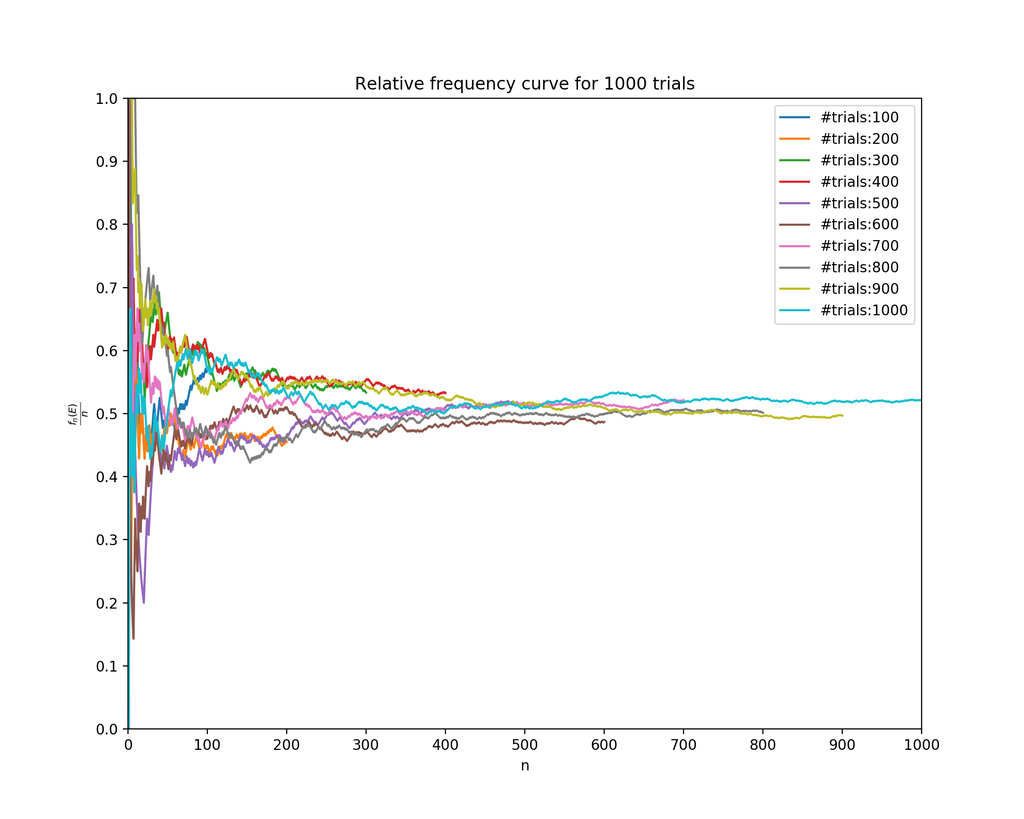

```
<function __main__.plotRelFreq(n)>
```

```python
import numpy as np
import matplotlib.pyplot as plt
from ipywidgets import interact #,interactive, fixed, interact_manual
import ipywidgets as widgets
%matplotlib nbagg

def flip_coin():
    return np.random.choice(['H','T'])

def coinRelFreq(n):
    x,rf=[],[]
    f=0
    for i in range(1,n+1):
        outcome=flip_coin()
        if outcome == 'H':
            f+=1
        rf.append(f/i)
        x.append(i)
    return (x,rf)
def plotRelFreq(n):
    if n>0:
        x,y=coinRelFreq(n)
        plt.title("Relative frequency curve for {0} trials".format(n))
        plt.plot(x,y,label="#trials:{0}".format(n))
        plt.legend(loc='upper right')

plt.figure(figsize=(10,8))
plt.xlabel("n")
plt.ylabel(r"$\frac{f_{n}(E)}{n}$")
plt.xlim(0,1000)
plt.ylim(0,1)
plt.xticks([i for i in range(0,1001,100)])
plt.yticks([0.0,0.1,0.2,0.3,0.4,0.5,0.6,0.7,0.8,0.9,1.0])
plt.show()
interact(plotRelFreq,n=widgets.IntSlider(min=0, max=1000, step=100, value=0,description='#trials:'))
```

This relative frequency approach intuitively make sense and it is very practical approach, but to be able to use this definition to compute probability, one has to perform experiment a large number of times, which may not be feasible and this relative frequency approach is not suitable for developing mathematical theory of probability. So we are not going to start with this definition.  
**Drawbacks of Relative frequency approach:**

- Actual observation of the experiment may not be possible
- Experiment may be too costly to perform,then cannot afford to repeat it large number of times.
- we don't know if limit always exists (*actually we will show later in this course (using Law of Large numbers) that this limit indeed exist in some probability sense*)